# Ensemble Learning

Applied Machine Learning in Economics

We are going to show to work with a regression ensemble using our lecture data to predict house values.

# 1 Setup

Use the same exact setup as from the Random Forest lecture. Omit the package `xgboost` and add `glmnet` and `class`.

# 2 Base Learners

Let’s try a few different base learner models:

1. Random Forest
2. KNN
3. OLS from a lasso regression

For all models, use this `formula`

```r
f = log(value) ~ lcost + npeople + lhinc + beds + baths + leqvval + lotsize + yos + hoa + condo + garage + bld + crime + math + hinf + houtf
```

## 2.1 Random Forest

Fit the model below.

```r
system.time({
fit_rf = randomForest(f, data = train, mtry = sqrt(16), ntree = 490)
})
```

```
##    user  system elapsed
##   25.28    0.05   25.35
```

```r
( mse_rf = mse(fit_rf, test) )
```

```
## [1] 0.8446881
```

## 2.2 KNN

And this one:

```r
trControl = trainControl(method = 'cv',
                         number = 5)

x_train = model.matrix(f, data = train)
y_train = log(train$value)


x_test = model.matrix(f, data = test)
y_test = log(test$value)

fit_knn_cv = train(x_train,
                   y_train,
                   method = 'knn',
                   tuneGrid = expand.grid(k = c(5, 10, 15, 20, 30)),
                   trControl = trControl)
fit_knn_cv$bestTune
```

```
##    k
## 2 10
```

```r
k_best = fit_knn_cv$bestTune$k

fit_knn = knn(x_train, x_test, y_train, k = k_best)
yhat_knn = fit_knn %>% as.character %>% as.numeric

( mse_knn = mean((yhat_knn - y_test)^2) )
```

```
## [1] 1.595633
```

## 2.3 Regularized OLS

And finally, this one.

```r
fit_ols_cv = train(x_train,
                   y_train,
                   method = 'glmnet',
                   trControl = trControl,
                   tuneGrid = expand.grid(alpha = 1, lambda = 10^seq(-8, 5, length = 50)),
                   data = train)
fit_ols_cv$bestTune
```

```
##    alpha      lambda
## 22     1 0.003727594
```

```r
fit_ols_reg = glmnet(x_train, y_train, alpha = 1, lambda = fit_ols_cv$bestTune$lambda)

coef(fit_ols_reg)
```

```
## 21 x 1 sparse Matrix of class "dgCMatrix"
##                            s0
## (Intercept)      1.6854515767
## (Intercept)      .
## lcost            0.4641234949
## npeople         -0.0369667220
## lhinc            0.0404420625
## beds             0.0272133082
## baths            .
## leqvval          0.5166849692
## lotsize          0.0123608051
## yos              0.0270068788
## hoaTRUE         -0.0222116153
## condoTRUE       -0.0708883234
## garageTRUE       0.0758921550
## bldApt >= 10     0.0284409312
## bldAttached SFH -0.0198498283
## bldDetached SFH  0.0402240234
## bldMobile Home  -1.4558122815
## crime           -0.0004568093
## math             0.0023431163
## hinf             .
## houtf            .
```

```r
f2 = log(value) ~ lcost + npeople + lhinc + beds + leqvval + lotsize + yos + hoa + condo + garage + bld + crime + math

fit_ols = lm(f2, train)

( mse_ols = mse(fit_ols, test) )
```

```
## [1] 0.925969
```

# 3 Ensemble Learning

Here we will compare three different *stacking* ensemble methods:

1. averaging
2. weighted averaging
3. model-aggregating via OLS

Obtain the predicted values for our three fitted models at `yhat_rf`, `yhat_knn`, and `yhat_ols` respectively.

## 3.1 Averaging

Calculate the averaging-ensemble MSE.

## 3.2 Weighted Averaging

In order to perform weighted averaging, we need to identify the optimal weights. We do this by cross validating. Unfortunately, I do not know of a any packages that will do it for us. Therefore, it is up to us!

Figure out how to do this on your own!

Just kidding… Here you go. If you can figure out a more efficient way to do this, within a week from today, I’ll give you 1% extra credit for the entire course.

So, basically the first step is to create the weights. I am going to brute force with `expand.grid()` and then remove the rows that don’t sum exactly to 1. Then I am going to use nested `for` loop for the CV on train.

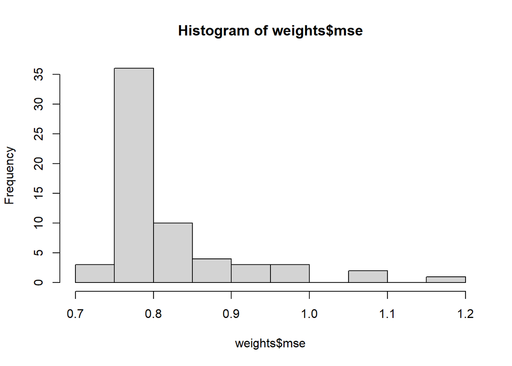

```r
# Creating a grid of weights for our three models
weights = expand.grid(w1 = seq(0, 1, by = 0.1),
                      w2 = seq(0, 1, by = 0.1),
                      w3 = seq(0, 1, by = 0.1))
weights = weights %>%
  mutate(w_tot = w1 + w2 + w3,
         mse   = NaN) %>%
  filter(w_tot == 1) %>%
  select(-w_tot)


# Setting up the k-fold cross validation
k_folds = 5
cv_results = matrix(NaN, ncol = k_folds, nrow = nrow(weights))
                    # using NaN so I can tell if there is a mistake

# Grabbing the "training" data
yhat_train = cbind(fit_rf$predicted,
                   as.numeric(as.character(knn(x_train, x_train, y_train, k = k_best))),
                   predict(fit_ols_reg, x_train))
# wouldn't it be nice if they just used the same call?

# Setting up the sample splitting: which rows should I grab?
index = sample(1:k_folds, nrow(train), replace = TRUE)
for(w in 1:nrow(weights)){
  for(k in 1:k_folds){
    i = which(index == k)
    # Some cheeky matrix multiplication to save time
    yhat = yhat_train[i, ] %*% t(weights[w, 1:3])

    # Storing the results
    cv_results[w, k] = mean( (yhat - y_train[i])^2 )
  }
  weights$mse[w] = mean(cv_results[w, ])
}
hist(weights$mse)
```

Identify which weights produce the minimum MSE.

Use these identified weights to compute the test MSE.

## 3.3 Model-Aggregation Ensemble

Finally, we will use OLS to “choose” the weights on the predicted values. Remember the OLS will fit coefficients to each covariate. It happens to be the case that the covariates are predicted values. OLS will also fit an intercept term or a “bias” term. This is four parameters chosen. They will not add to one. Importantly, OLS does this by minimizing MSE.

1. fit a linear model on `y_train` and `yhat_train`.
   1. produce a summary to identify the loadings
2. create a new `yhat_test` the same way `yhat_train` was created. The ordering matters
3. predict the new MSE

# 4 Comparisons

Print the MSEs for each base learner and the different ensembles. Which ensembles performed better than the best base learner alone? Which was the best performing model overall?